# Лекция № 5

# 1 Введение в библиотеку Pandas

[figure not shown]

Pandas - более новый пакет, надстройка над библиотекой NumPy, обеспечивающий эффективную реализацию класса `DataFrame`.

Объекты `DataFrame` - многомерные массивы с метками для строк и столбцов, а также зачастую с неоднородным типом данных и/или пропущенными данными. Помимо удобного интерфейса для хранения маркированных данных, библиотека Pandas реализует множество операций для работы с данными хорошо знакомых пользователям фреймворков баз данных и электронных таблиц.

Структура данных `ndarray` библиотеки NumPy предоставляет все необходимые возможности для работы с хорошо упорядоченными данными в задачах численных вычислений. Для этой цели библиотека NumPy отлично подходит, однако имеет свои ограничения, которые становятся заметными, чуть только нам потребуется немного больше гибкости (маркирование данных, работа с пропущенными данными и т. д.). Эти ограничения проявляются также при попытках выполнения операций, неподходящих для поэлементного транслирования (группировки, создание сводных таблиц и т. д.). Такие операции являются важной частью анализа данных с меньшей степенью структурированности, содержащихся во многих формах окружающего мира.

Библиотека Pandas, особенно ее объекты `Series` и `DataFrame`, основана на структурах массивов библиотеки NumPy и обеспечивает эффективную работу над подобными задачами "очистки данных".

```python
import pandas as pd
import numpy as np
```

## 1.1 Объект `Series`

Объект `Series` библиотеки Pandas - одномерный массив индексированных данных. Его можно создать из списка или массива следующим образом:

```python
data = pd.Series([0.25, 0.5, 0.75, 1, 1.25])
data
```

```
0    0.25
1    0.50
2    0.75
3    1.00
4    1.25
dtype: float64
```

объект `Series` служит контейнером как для последовательности значений, так и последовательности индексов, к которым можно получить доступ посредством атрибутов `values` и `index`.

Атрибут `values` представляет собой уже знакомый нам массив NumPy:

```python
data.values
```

```
array([0.25, 0.5 , 0.75, 1.  , 1.25])
```

`index` - массивоподобный объект типа `pd.Index`, который мы рассмотрим подробнее далее:

```python
data.index
```

```
RangeIndex(start=0, stop=5, step=1)
```

Аналогично массивам библиотеки NumPy, к данным можно обращаться по соответствующему им индексу посредством нотации с использованием квадратных скобок языка Python:

```python
data[1]
```

```
0.5
```

```python
data[1:3]
```

```
1    0.50
2    0.75
dtype: float64
```

Однако объект `Series` библиотеки Pandas намного универсальнее и гибче, чем эмулируемый им одномерный массив библиотеки NumPy.

Может показаться, что объект `Series` и одномерный массив библиотеки NumPy взаимозаменяемы. Основное различие между ними - *индекс*. В то время как индекс массива NumPy, используемый для доступа к значениям, целочисленный и описывается неявно, индекс объекта `Series` библиотеки Pandas описывается явно и связывается со значениями.

Явное описание индекса расширяет возможности объекта `Series`. Такой индекс не должен быть целым числом, а может состоять из значений любого нужного типа. Например, при желании мы можем использовать в качестве индекса строковые значения:

```python
data = pd.Series([0.25, 0.5, 0.75, 1.0],
                 index=['a', 'b', 'c', 'd'])
data
```

```
a    0.25
b    0.50
c    0.75
d    1.00
dtype: float64
```

При этом доступ к элементам работает обычным образом:

```python
data['c']
```

```
0.75
```

Можно применять даже индексы, состоящие из несмежных или непоследовательных значений:

```python
data = pd.Series(
    [0.25, 0.5, 0.75, 1.0],
    index=[2, 5, 3, 7]
)
data
```

```
2    0.25
5    0.50
3    0.75
7    1.00
dtype: float64
```

```python
data[3]
```

```
0.75
```

### 1.1.1 Объект `Series` как специализированный словарь

Объект `Series` библиотеки Pandas можно рассматривать как специализированную разновидность словаря языка Python. **Словарь** - структура, задающая соответствие произвольных ключей набору произвольных значений, а объект `Series` - структура, задающая соответствие типизированных ключей набору типизированных значений.

> Типизация важна: точно так же, как соответствующий типу специализированный код для массива библиотеки NumPy при выполнении определенных операций делает его эффективнее, чем стандартный список Python, информация о типе в объекте `Series` библиотеки Pandas делает его намного более эффективным для определенных операций, чем словари Python.

Можно сделать аналогию "объект `Series` - словарь" еще более наглядной, сконструировав объект `Series` непосредственно из *словаря* Python:

```python
population_dict = {
    'California': 38332521,
    'Texas': 26448193,
    'New York': 19651127,
    'Florida': 19552860,
    'Illinois': 12882135
}
population = pd.Series(population_dict)
population
```

```
California    38332521
Texas         26448193
New York      19651127
Florida       19552860
Illinois      12882135
dtype: int64
```

```python
population['California']
```

```
38332521
```

Однако, в отличие от словаря, объект `Series` поддерживает характерные для массивов операции, такие как срезы:

```python
population['California':'Illinois']
```

```
California    38332521
Texas         26448193
New York      19651127
Florida       19552860
Illinois      12882135
dtype: int64
```

### 1.1.2 Создание объектов `Series`

Мы уже изучили несколько способов создания объектов `Series` библиотеки Pandas с нуля. Все они представляют собой различные варианты следующего синтаксиса:

```
pd.Series(data, index=index)
```

где `index` - необязательный аргумент, а `data` может быть одной из множества сущностей.

Например, аргумент `data` может быть списком или массивом NumPy. В этом случае `index` по умолчанию будет целочисленной последовательностью:

```python
pd.Series([2, 4, 6])
```

```
0    2
1    4
2    6
dtype: int64
```

Аргумент `data` может быть скалярным значением, которое будет повторено нужное количество раз для заполнения заданного индекса:

```python
pd.Series(10, index=[1, 2, 3])
```

```
1    10
2    10
3    10
dtype: int64
```

Аргумент `data` может быть словарем, в котором `index` по умолчанию является ключами этого словаря:

```python
pd.Series({2: 'a', 1: 'b', 3: 'c'})
```

```
2    a
1    b
3    c
dtype: object
```

В каждом случае индекс можно указать вручную, если необходимо получить другой результат:

```python
pd.Series({2: 'a', 1: 'b', 3: 'c'}, index=[3, 2])
```

```
3    c
2    a
dtype: object
```

> Обратите внимание, что объект `Series` заполняется только заданными явным образом ключами.

## 1.2 Объект `DataFrame`

Следующая базовая структура библиотеки Pandas - объект `DataFrame`. Как и объект `Series`, обсуждавшийся в предыдущей секции, объект `DataFrame` можно рассматривать или как обобщение массива NumPy, или как специализированную версию *словаря* Python.

### 1.2.1 `DataFrame` как обобщенный массив NumPy

Если объект `Series` - аналог одномерного массива с гибкими индексами, объект `DataFrame` - аналог двумерного массива с гибкими индексами строк и гибкими именами столбцов. Аналогично тому, что двумерный массив можно рассматривать как упорядоченную последовательность выровненных столбцов, объект `DataFrame` можно рассматривать как упорядоченную последовательность выровненных объектов `Series`. Под "выровненными" имеется в виду то, что они используют один и тот же индекс.

Чтобы продемонстрировать это, сначала создадим новый объект `Series`, содержащий площадь каждого из пяти упомянутых в предыдущем разделе штатов:

```python
area_dict = {
    'California': 423967,
    'Texas': 695662,
    'New York': 141297,
    'Florida': 170312,
    'Illinois': 149995
}
area = pd.Series(area_dict)
area
```

```
California    423967
Texas         695662
New York      141297
Florida       170312
Illinois      149995
dtype: int64
```

Воспользовавшись объектом `population` класса `Series`, сконструируем на основе словаря единый двумерный объект, содержащий всю эту информацию:

```python
states = pd.DataFrame(
    {
        'population': population,
        'area': area
    }
)
states
```

|  | population | area |
| --- | --- | --- |
| California | 38332521 | 423967 |
| Texas | 26448193 | 695662 |
| New York | 19651127 | 141297 |
| Florida | 19552860 | 170312 |
| Illinois | 12882135 | 149995 |

Аналогично объекту `Series` у объекта `DataFrame` имеется атрибут `index`, обеспечивающий доступ к меткам индекса:

```python
states.index
```

```
Index(['California', 'Texas', 'New York', 'Florida', 'Illinois'], dtype='object')
```

Помимо этого, у объекта `DataFrame` есть атрибут `columns`, представляющий собой содержащий метки столбцов объект `Index`:

```python
states.columns
```

```
Index(['population', 'area'], dtype='object')
```

Таким образом, объект `DataFrame` можно рассматривать как обобщение двумерного массива NumPy, где как у строк, так и у столбцов есть обобщенные индексы для доступа к данным.

### 1.2.2 Объект `DataFrame` как специализированный словарь

`DataFrame` можно рассматривать как специализированный словарь. Если словарь задает соответствие ключей значениям, то `DataFrame` задает соответствие имени столбца объекту `Series` с данными этого столбца. Например, запрос данных по атрибуту `'area'` приведет к тому, что будет возвращен объект `Series`, содержащий уже виденные нами ранее площади штатов:

```python
states['area']
```

```
California    423967
Texas         695662
New York      141297
Florida       170312
Illinois      149995
Name: area, dtype: int64
```

Обратите внимание на возможный источник путаницы: в двумерном массиве NumPy `data[0]` возвращает первую *строку*. По этой причине объекты `DataFrame` лучше рассматривать как обобщенные словари, а не обобщенные массивы, хотя обе точки зрения имеют право на жизнь.

### 1.2.3 Создание объектов `DataFrame`

##### Из одного объекта `Series`.

Объект `DataFrame` - набор объектов `Series`. `DataFrame`, состоящий из одного столбца, можно создать на основе одного объекта `Series`:

```python
pd.DataFrame(population, columns=['population'])
```

|  | population |
| --- | --- |
| California | 38332521 |
| Texas | 26448193 |
| New York | 19651127 |
| Florida | 19552860 |
| Illinois | 12882135 |

##### Из списка словарей

Любой список словарей можно преобразовать в объект `DataFrame`. Мы воспользуемся простым генератором списка для создания данных:

```python
data = [{'a': i, 'b': 2 * i} for i in range(3)]
pd.DataFrame(data)
```

|  | a | b |
| --- | --- | --- |
| 0 | 0 | 0 |
| 1 | 1 | 2 |
| 2 | 2 | 4 |

Даже если некоторые ключи в словаре отсутствуют, библиотека Pandas просто заполнит их значениями `NaN` (то есть Not a number~-- "не является числом"):

```python
pd.DataFrame([{'a': 1, 'b': 2}, {'b': 3, 'c': 4}])
```

|  | a | b | c |
| --- | --- | --- | --- |
| 0 | 1.0 | 2 | NaN |
| 1 | NaN | 3 | 4.0 |

##### Из словаря объектов `Series`

Объект `DataFrame` также можно создать на основе словаря объектов `Series`:

```python
pd.DataFrame(
    {
        'population': population,
        'area': area
    }
)
```

|  | population | area |
| --- | --- | --- |
| California | 38332521 | 423967 |
| Texas | 26448193 | 695662 |
| New York | 19651127 | 141297 |
| Florida | 19552860 | 170312 |
| Illinois | 12882135 | 149995 |

##### Из двумерного массива NumPy

Если у нас есть двумерный массив данных, мы можем создать объект `DataFrame` с любыми заданными именами столбцов и индексов. Для каждого из пропущенных значений будет использоваться целочисленный индекс:

```python
pd.DataFrame(
    np.random.rand(3, 2),
    columns=['one', 'two'],
    index=['a', 'b', 'c']
)
```

|  | one | two |
| --- | --- | --- |
| a | 0.981130 | 0.755774 |
| b | 0.949854 | 0.443188 |
| c | 0.137210 | 0.048252 |

## 1.3 Объект `Index`

Как объект `Series`, так и объект `DataFrame` содержат явный индекс, обеспечивающий возможность ссылаться на данные и модифицировать их. Объект `Index` можно рассматривать или как *неизменяемый массив* (**immutable array**), или как *упорядоченное множество* (**ordered set**) (формально мультимножество, так как объекты `Index` могут содержать повторяющиеся значения). Из этих способов его представления следуют некоторые интересные возможности операций над объектами `Index`. В качестве простого примера создадим `Index` из списка целых чисел:

```python
ind = pd.Index([2, 3, 5, 7, 11])
ind
```

```
Int64Index([2, 3, 5, 7, 11], dtype='int64')
```

### 1.3.1 Объект `Index` как неизменяемый массив

Объект `Index` во многом ведет себя аналогично массиву. Например, для извлечения из него значений или срезов можно использовать стандартную нотацию индексации языка Python:

```python
ind[1]
```

```
3
```

```python
ind[::2]
```

```
Int64Index([2, 5, 11], dtype='int64')
```

У объектов `Index` есть много атрибутов, знакомых нам по массивам NumPy:

```python
ind.size, ind.shape, ind.ndim, ind.dtype
```

```
(5, (5,), 1, dtype('int64'))
```

Одно из различий между объектами `Index` и массивами NumPy - неизменяемость индексов, то есть их нельзя модифицировать стандартными средствами:

```python
ind[2] = 0
```

```
---------------------------------------------------------------------------
TypeError                                 Traceback (most recent call last)
Cell In[32], line 1
----> 1 ind[2] = 0

File ~\anaconda3\lib\site-packages\pandas\core\indexes\base.py:5302, in Index.__setitem__(self, key, value)
   5300 @final
   5301 def __setitem__(self, key, value):
-> 5302     raise TypeError("Index does not support mutable operations")

TypeError: Index does not support mutable operations
```

Неизменяемость делает безопаснее совместное использование индексов несколькими объектами `DataFrame` и массивами, исключая возможность побочных эффектов в виде случайной модификации индекса по неосторожности.

Объекты библиотеки Pandas спроектированы с прицелом на упрощение таких операций, как соединения наборов данных, зависящие от многих аспектов арифметики множеств. Объект `Index` следует большинству соглашений, используемых встроенной структурой данных `set` языка Python, так что объединения, пересечения, разности и другие операции над множествами можно выполнять привычным образом:

```python
indA = pd.Index([1, 3, 5, 7, 9])
indB = pd.Index([2, 3, 5, 7, 11])
```

```python
indA.intersection(indB)
```

```
Int64Index([3, 5, 7], dtype='int64')
```

```python
indA.union(indB)
```

```
Int64Index([1, 2, 3, 5, 7, 9, 11], dtype='int64')
```

```python
indA.symmetric_difference(indB)
```

```
Int64Index([1, 2, 9, 11], dtype='int64')
```

## 1. 4 Выборка данных из объекта `DataFrame`

Объект `DataFrame` во многом ведет себя аналогично двумерному или структурированному массиву, а также словарю объектов `Series` с общим индексом. Эти аналогии следует иметь в виду во время изучения способов выборки данных из объекта.

### 1.4.1 Объект `DataFrame` как словарь

Первая аналогия, которую мы будем обсуждать, объект `DataFrame` как словарь схожих между собой объектов `Series`. Вернемся к примеру про площадь и численность населения штатов:

```python
area = pd.Series(
    {
        'California': 423967,
        'Texas': 695662,
        'New York': 141297,
        'Florida': 170312,
        'Illinois': 149995
    }
)
pop = pd.Series(
    {
        'California': 38332521,
        'Texas': 26448193,
        'New York': 19651127,
        'Florida': 19552860,
        'Illinois': 12882135
    }
)
data = pd.DataFrame({'area': area, 'pop': pop})
data
```

|  | area | pop |
| --- | --- | --- |
| California | 423967 | 38332521 |
| Texas | 695662 | 26448193 |
| New York | 141297 | 19651127 |
| Florida | 170312 | 19552860 |
| Illinois | 149995 | 12882135 |

К отдельным объектам `Series`, составляющим столбцы объекта `DataFrame`, можно обращаться посредством такой же индексации, как и для словарей, по имени столбца:

```python
data['area']
```

```
California    423967
Texas         695662
New York      141297
Florida       170312
Illinois      149995
Name: area, dtype: int64
```

Можно обращаться к данным и с помощью атрибутов, используя в их качестве строковые имена столбцов:

```python
data.area
```

```
California    423967
Texas         695662
New York      141297
Florida       170312
Illinois      149995
Name: area, dtype: int64
```

Хотя это и удобное сокращенное написание, не забывайте, что оно работает не всегда! Например, если имена столбцов - не строки или имена столбцов конфликтуют с методами объекта `DataFrame`, доступ по именам атрибутов **невозможен**. Например, у объекта `DataFrame` есть метод `pop()`, так что выражение `data.pop` будет обозначать его, а не столбец `'pop'`:

```python
data.pop is data['pop']
```

```
False
```

Такой «словарный» синтаксис можно применять для модификации объекта, например добавления еще одного столбца:

```python
data['density'] = data['pop'] / data['area']
data
```

|  | area | pop | density |
| --- | --- | --- | --- |
| California | 423967 | 38332521 | 90.413926 |
| Texas | 695662 | 26448193 | 38.018740 |
| New York | 141297 | 19651127 | 139.076746 |
| Florida | 170312 | 19552860 | 114.806121 |
| Illinois | 149995 | 12882135 | 85.883763 |

### 1.4.2 Объект `DataFrame` как двумерный массив

Объект `DataFrame` можно рассматривать как двумерный массив с расширенными возможностями. Посмторим на исходный массив данных с помощью атрибута `values`:

```python
data.values
```

```
array([[4.23967000e+05, 3.83325210e+07, 9.04139261e+01],
       [6.95662000e+05, 2.64481930e+07, 3.80187404e+01],
       [1.41297000e+05, 1.96511270e+07, 1.39076746e+02],
       [1.70312000e+05, 1.95528600e+07, 1.14806121e+02],
       [1.49995000e+05, 1.28821350e+07, 8.58837628e+01]])
```

Мы можем выполнить множество привычных для массивов действий над объектом `DataFrame`. Например, транспонировать весь `DataFrame`, поменяв местами строки и столбцы:

```python
data.T
```

|  | California | Texas | New York | Florida | Illinois |
| --- | --- | --- | --- | --- | --- |
| area | 4.239670e+05 | 6.956620e+05 | 1.412970e+05 | 1.703120e+05 | 1.499950e+05 |
| pop | 3.833252e+07 | 2.644819e+07 | 1.965113e+07 | 1.955286e+07 | 1.288214e+07 |
| density | 9.041393e+01 | 3.801874e+01 | 1.390767e+02 | 1.148061e+02 | 8.588376e+01 |

Однако, когда речь заходит об индексации объектов `DataFrame`, становится ясно, что словарная индексация мешает нам рассматривать их просто как массивы NumPy. В частности, указание отдельного индекса для массива означает доступ к строке:

```python
data.values[0]
```

```
array([4.23967000e+05, 3.83325210e+07, 9.04139261e+01])
```

а указание отдельного «индекса» для объекта `DataFrame` - доступ к столбцу:

```python
data['pop']
```

```
California    38332521
Texas         26448193
New York      19651127
Florida       19552860
Illinois      12882135
Name: pop, dtype: int64
```

Таким образом, нам необходим еще один тип синтаксиса для индексации, аналогичной по стилю индексации массивов. Библиотека Pandas применяет индексаторы `loc`, `iloc`.

- С помощью индексатора `iloc` можно индексировать исходный массив, как будто это простой массив NumPy (используя неявный синтаксис языка Python), но с сохранением в результирующих данных меток объекта `DataFrame` для индекса и столбцов:

```python
data.iloc[:3, :2]
```

|  | area | pop |
| --- | --- | --- |
| California | 423967 | 38332521 |
| Texas | 695662 | 26448193 |
| New York | 141297 | 19651127 |

```python
data.loc[:'Illinois', :'pop']
```

|  | area | pop |
| --- | --- | --- |
| California | 423967 | 38332521 |
| Texas | 695662 | 26448193 |
| New York | 141297 | 19651127 |
| Florida | 170312 | 19552860 |
| Illinois | 149995 | 12882135 |

## 1.3 Как читать и записывать табличные данные?

### 1.3.1 Работа с csv-файлами и тектсовыми/табличными данными

Данные со значениями, разделенными разделителем (CSV-данные), являются, вероятно, одним из наиболее распространенных форматов данных, который вы будете использовать в библиотеке pandas. Многие веб-сервисы, а также внутрикорпоративные информационные системы предлагают загрузить данные в формате CSV. Это простой формат, который обычно используется для экспорта данных из электронных таблиц типа Excel.

CSV-файл - это файл, который содержит значения, разделенные запятыми. Его можно рассматривать как таблицу данных, аналогичную листу электронной таблицы. Каждая строка данных соответствует строке файла, каждый столбец хранится в текстовом формате, при этом данные в каждом столбце разделены запятыми.

В этом руководстве используется набор данных Titanic, сохраненный в формате CSV. Данные состоят из следующих столбцов:

PassengerId: Идентификатор каждого пассажира.

Survived: Имеет значения 0 и 1. 0 для не выживших и 1 для выживших.

Pclass: Существует 3 класса: класс 1, класс 2 и класс 3.

Name: Имя пассажира.

Gender: Пол пассажира.

Age: Возраст пассажира.

SibSp: Указание на то, что у пассажира есть братья, сестры и супруг.

Parch: Пассажир один или с семьей.

Ticket: Номер билета пассажира.

Fare: Указание тарифа.

Cabin: Каюта пассажира.

Embarked: Категория причала.

[figure not shown]

##### Чтение CSV-фаайла в `DataFrame`

```python
titanic = pd.read_csv("titanic.csv")
```

pandas предоставляет функцию `read_csv()` для чтения данных, хранящихся в виде CSV-файла, в `DataFrame`.

Pandas поддерживает множество различных форматов файлов или источников данных из коробки (csv, excel, sql, json, parquet и так далее), каждый из них имеет префикс `read_*`.

Всегда проверяйте данные после их чтения. При отображении `DataFrame` по умолчанию будут отображаться первые и последние 5 строк:

```python
titanic
```

|  | PassengerId | Survived | Pclass | Name | Gender | Age | SibSp | Parch | Ticket | Fare | Cabin | Embarked |
| --- | --- | --- | --- | --- | --- | --- | --- | --- | --- | --- | --- | --- |
| 0 | 1 | 0 | 3 | Braund, Mr. Owen Harris | male | 22.0 | 1 | 0 | A/5 21171 | 7.2500 | NaN | S |
| 1 | 2 | 1 | 1 | Cumings, Mrs. John Bradley (Florence Briggs Th... | female | 38.0 | 1 | 0 | PC 17599 | 71.2833 | C85 | C |
| 2 | 3 | 1 | 3 | Heikkinen, Miss. Laina | female | 26.0 | 0 | 0 | STON/O2. 3101282 | 7.9250 | NaN | S |
| 3 | 4 | 1 | 1 | Futrelle, Mrs. Jacques Heath (Lily May Peel) | female | 35.0 | 1 | 0 | 113803 | 53.1000 | C123 | S |
| 4 | 5 | 0 | 3 | Allen, Mr. William Henry | male | 35.0 | 0 | 0 | 373450 | 8.0500 | NaN | S |
| ... | ... | ... | ... | ... | ... | ... | ... | ... | ... | ... | ... | ... |
| 886 | 887 | 0 | 2 | Montvila, Rev. Juozas | male | 27.0 | 0 | 0 | 211536 | 13.0000 | NaN | S |
| 887 | 888 | 1 | 1 | Graham, Miss. Margaret Edith | female | 19.0 | 0 | 0 | 112053 | 30.0000 | B42 | S |
| 888 | 889 | 0 | 3 | Johnston, Miss. Catherine Helen "Carrie" | female | NaN | 1 | 2 | W./C. 6607 | 23.4500 | NaN | S |
| 889 | 890 | 1 | 1 | Behr, Mr. Karl Howell | male | 26.0 | 0 | 0 | 111369 | 30.0000 | C148 | C |
| 890 | 891 | 0 | 3 | Dooley, Mr. Patrick | male | 32.0 | 0 | 0 | 370376 | 7.7500 | NaN | Q |

891 rows × 12 columns

Чтобы просмотреть первые N строк `DataFrame`, используйте метод `head()` с требуемым количеством строк (в данном случае 8) в качестве аргумента.

```python
titanic.head(8)
```

|  | PassengerId | Survived | Pclass | Name | Gender | Age | SibSp | Parch | Ticket | Fare | Cabin | Embarked |
| --- | --- | --- | --- | --- | --- | --- | --- | --- | --- | --- | --- | --- |
| 0 | 1 | 0 | 3 | Braund, Mr. Owen Harris | male | 22.0 | 1 | 0 | A/5 21171 | 7.2500 | NaN | S |
| 1 | 2 | 1 | 1 | Cumings, Mrs. John Bradley (Florence Briggs Th... | female | 38.0 | 1 | 0 | PC 17599 | 71.2833 | C85 | C |
| 2 | 3 | 1 | 3 | Heikkinen, Miss. Laina | female | 26.0 | 0 | 0 | STON/O2. 3101282 | 7.9250 | NaN | S |
| 3 | 4 | 1 | 1 | Futrelle, Mrs. Jacques Heath (Lily May Peel) | female | 35.0 | 1 | 0 | 113803 | 53.1000 | C123 | S |
| 4 | 5 | 0 | 3 | Allen, Mr. William Henry | male | 35.0 | 0 | 0 | 373450 | 8.0500 | NaN | S |
| 5 | 6 | 0 | 3 | Moran, Mr. James | male | NaN | 0 | 0 | 330877 | 8.4583 | NaN | Q |
| 6 | 7 | 0 | 1 | McCarthy, Mr. Timothy J | male | 54.0 | 0 | 0 | 17463 | 51.8625 | E46 | S |
| 7 | 8 | 0 | 3 | Palsson, Master. Gosta Leonard | male | 2.0 | 3 | 1 | 349909 | 21.0750 | NaN | S |

> Если нужно проверить последние N строк, а не первые, используйте метод `tail()`. Например, `titanic.tail(10)` вернет последние 10 строк `DataFrame`.

```python
titanic.tail(10)
```

|  | PassengerId | Survived | Pclass | Name | Gender | Age | SibSp | Parch | Ticket | Fare | Cabin | Embarked |
| --- | --- | --- | --- | --- | --- | --- | --- | --- | --- | --- | --- | --- |
| 881 | 882 | 0 | 3 | Markun, Mr. Johann | male | 33.0 | 0 | 0 | 349257 | 7.8958 | NaN | S |
| 882 | 883 | 0 | 3 | Dahlberg, Miss. Gerda Ulrika | female | 22.0 | 0 | 0 | 7552 | 10.5167 | NaN | S |
| 883 | 884 | 0 | 2 | Banfield, Mr. Frederick James | male | 28.0 | 0 | 0 | C.A./SOTON 34068 | 10.5000 | NaN | S |
| 884 | 885 | 0 | 3 | Sutehall, Mr. Henry Jr | male | 25.0 | 0 | 0 | SOTON/OQ 392076 | 7.0500 | NaN | S |
| 885 | 886 | 0 | 3 | Rice, Mrs. William (Margaret Norton) | female | 39.0 | 0 | 5 | 382652 | 29.1250 | NaN | Q |
| 886 | 887 | 0 | 2 | Montvila, Rev. Juozas | male | 27.0 | 0 | 0 | 211536 | 13.0000 | NaN | S |
| 887 | 888 | 1 | 1 | Graham, Miss. Margaret Edith | female | 19.0 | 0 | 0 | 112053 | 30.0000 | B42 | S |
| 888 | 889 | 0 | 3 | Johnston, Miss. Catherine Helen "Carrie" | female | NaN | 1 | 2 | W./C. 6607 | 23.4500 | NaN | S |
| 889 | 890 | 1 | 1 | Behr, Mr. Karl Howell | male | 26.0 | 0 | 0 | 111369 | 30.0000 | C148 | C |
| 890 | 891 | 0 | 3 | Dooley, Mr. Patrick | male | 32.0 | 0 | 0 | 370376 | 7.7500 | NaN | Q |

Проверить, как pandas интерпретирует каждый из типов данных столбца, можно, запросив атрибут pandas `dtypes`:

```python
titanic.dtypes
```

```
PassengerId      int64
Survived         int64
Pclass           int64
Name            object
Gender          object
Age            float64
SibSp            int64
Parch            int64
Ticket          object
Fare           float64
Cabin           object
Embarked        object
dtype: object
```

Для каждого столбца указывается используемый тип данных. Типы данных в этом `DataFrame`: целые числа (`int64`), числа с плавающей запятой (`float64`) и строки (`object`).

##### Указание столбца индексов при чтении CSV-файлов

```python
pd.read_csv('titanic.csv', index_col='Name')
```

| Name | PassengerId | Survived | Pclass | Gender | Age | SibSp | Parch | Ticket | Fare | Cabin | Embarked |
| --- | --- | --- | --- | --- | --- | --- | --- | --- | --- | --- | --- |
| Braund, Mr. Owen Harris | 1 | 0 | 3 | male | 22.0 | 1 | 0 | A/5 21171 | 7.2500 | NaN | S |
| Cumings, Mrs. John Bradley (Florence Briggs Thayer) | 2 | 1 | 1 | female | 38.0 | 1 | 0 | PC 17599 | 71.2833 | C85 | C |
| Heikkinen, Miss. Laina | 3 | 1 | 3 | female | 26.0 | 0 | 0 | STON/O2. 3101282 | 7.9250 | NaN | S |
| Futrelle, Mrs. Jacques Heath (Lily May Peel) | 4 | 1 | 1 | female | 35.0 | 1 | 0 | 113803 | 53.1000 | C123 | S |
| Allen, Mr. William Henry | 5 | 0 | 3 | male | 35.0 | 0 | 0 | 373450 | 8.0500 | NaN | S |
| ... | ... | ... | ... | ... | ... | ... | ... | ... | ... | ... | ... |
| Montvila, Rev. Juozas | 887 | 0 | 2 | male | 27.0 | 0 | 0 | 211536 | 13.0000 | NaN | S |
| Graham, Miss. Margaret Edith | 888 | 1 | 1 | female | 19.0 | 0 | 0 | 112053 | 30.0000 | B42 | S |
| Johnston, Miss. Catherine Helen "Carrie" | 889 | 0 | 3 | female | NaN | 1 | 2 | W./C. 6607 | 23.4500 | NaN | S |
| Behr, Mr. Karl Howell | 890 | 1 | 1 | male | 26.0 | 0 | 0 | 111369 | 30.0000 | C148 | C |
| Dooley, Mr. Patrick | 891 | 0 | 3 | male | 32.0 | 0 | 0 | 370376 | 7.7500 | NaN | Q |

891 rows × 11 columns

##### Указание конкретных столбцов для загрузки

Можно указать, какие столбцы нужно загружать при чтении файла. Это может быть полезно, если файл содержит много столбцов, некоторые из которых не представляют интереса для вашего анализа, и вы хотите сэкономить время и память, необходимые для чтения и хранения этих данных.

Указать конкретные столбцы для загрузки можно с помощью параметра `usecols`, которому можно передан список имен столбцов или индексов столбцов.

```python
pd.read_csv('titanic.csv', usecols=['Name', 'Age'], index_col='Name')
```

| Name | Age |
| --- | --- |
| Braund, Mr. Owen Harris | 22.0 |
| Cumings, Mrs. John Bradley (Florence Briggs Thayer) | 38.0 |
| Heikkinen, Miss. Laina | 26.0 |
| Futrelle, Mrs. Jacques Heath (Lily May Peel) | 35.0 |
| Allen, Mr. William Henry | 35.0 |
| ... | ... |
| Montvila, Rev. Juozas | 27.0 |
| Graham, Miss. Margaret Edith | 19.0 |
| Johnston, Miss. Catherine Helen "Carrie" | NaN |
| Behr, Mr. Karl Howell | 26.0 |
| Dooley, Mr. Patrick | 32.0 |

891 rows × 1 columns

##### Сохранение данных

В то время как функции `read_*` используются для чтения данных в pandas, методы `to_*` используются для хранения данных.

- Метод `to_excel()` сохраняет данные в виде файла Excel.

В приведенном здесь примере `sheet_name` имеет значение `passengers`, а не предусмотренное по умолчанию `Sheet1`. При установке `index=False` в электронной таблице не сохраняются метки индексов строк.

```python
titanic.to_excel("titanic.xlsx", sheet_name="passengers", index=False)
```

Эквивалентная функция чтения `read_excel()` перезагрузит данные в `DataFrame`:

```python
titanic = pd.read_excel("titanic.xlsx", sheet_name="passengers")
```

Метод `info()` предоставляет техническую информацию о `DataFrame`:

```python
titanic.info()
```

```
<class 'pandas.core.frame.DataFrame'>
RangeIndex: 891 entries, 0 to 890
Data columns (total 12 columns):
 #   Column       Non-Null Count  Dtype
---  ------       --------------  -----
 0   PassengerId  891 non-null    int64
 1   Survived     891 non-null    int64
 2   Pclass       891 non-null    int64
 3   Name         891 non-null    object
 4   Gender       891 non-null    object
 5   Age          714 non-null    float64
 6   SibSp        891 non-null    int64
 7   Parch        891 non-null    int64
 8   Ticket       891 non-null    object
 9   Fare         891 non-null    float64
 10  Cabin        204 non-null    object
 11  Embarked     889 non-null    object
dtypes: float64(2), int64(5), object(5)
memory usage: 83.7+ KB
```

## 1.4 Выбор подмножества из `DataFrame`

### 1.4.1 Выбор определенных столбцов

[figure not shown]

Чтобы выбрать один столбец, используйте квадратные скобки `[]` с именем интересующего столбца.

Возраст пассажиров Титаника:

```python
ages = titanic["Age"]
```

```python
ages.head()
```

```
0    22.0
1    38.0
2    26.0
3    35.0
4    35.0
Name: Age, dtype: float64
```

Каждый столбец в `DataFrame` является `Series`. Поскольку выбран один столбец, возвращаемый объект представляет собой `Series`. Мы можем убедиться в этом, проверив тип вывода:

```python
type(titanic["Age"])
```

```
pandas.core.series.Series
```

И посмотрите на `shape` вывода:

```python
titanic["Age"].shape
```

```
(891,)
```

`DataFrame.shape` — это атрибут `Series` и `DataFrame` (вспомните урок по чтению и записи: круглые скобки для атрибутов не используются), содержащий количество строк и столбцов: (nrows, ncolumns). `Series` в pandas одномерна, так что возвращается только количество строк.

Чтобы выбрать несколько столбцов, используйте список имен столбцов в квадратных скобках `[]`.

Возраст и пол пассажиров Титаника:

```python
age_gender = titanic[["Age", "Gender"]]
```

```python
age_gender
```

|  | Age | Gender |
| --- | --- | --- |
| 0 | 22.0 | male |
| 1 | 38.0 | female |
| 2 | 26.0 | female |
| 3 | 35.0 | female |
| 4 | 35.0 | male |
| ... | ... | ... |
| 886 | 27.0 | male |
| 887 | 19.0 | female |
| 888 | NaN | female |
| 889 | 26.0 | male |
| 890 | 32.0 | male |

891 rows × 2 columns

Возвращаемый тип данных — `DataFrame`:

```python
type(age_gender)
```

```
pandas.core.frame.DataFrame
```

```python
age_gender.shape
```

```
(891, 2)
```

Выборка вернула `DataFrame` с 891 строкой и 2 столбцами. Помните, что `DataFrame` двумерный объект, где одно измерение - это строки, а другое - столбцы.

### 1.4.2 Как отфильтровать определенные строки из `DataFrame`?

[figure not shown]

Чтобы выбрать строки на основе условия, поместите условие в скобки выбора `[]`.

Пассажиры старше 35 лет:

```python
above_35 = titanic[titanic["Age"] > 35]
```

```python
above_35.head()
```

|  | PassengerId | Survived | Pclass | Name | Gender | Age | SibSp | Parch | Ticket | Fare | Cabin | Embarked |
| --- | --- | --- | --- | --- | --- | --- | --- | --- | --- | --- | --- | --- |
| 1 | 2 | 1 | 1 | Cumings, Mrs. John Bradley (Florence Briggs Th... | female | 38.0 | 1 | 0 | PC 17599 | 71.2833 | C85 | C |
| 6 | 7 | 0 | 1 | McCarthy, Mr. Timothy J | male | 54.0 | 0 | 0 | 17463 | 51.8625 | E46 | S |
| 11 | 12 | 1 | 1 | Bonnell, Miss. Elizabeth | female | 58.0 | 0 | 0 | 113783 | 26.5500 | C103 | S |
| 13 | 14 | 0 | 3 | Andersson, Mr. Anders Johan | male | 39.0 | 1 | 5 | 347082 | 31.2750 | NaN | S |
| 15 | 16 | 1 | 2 | Hewlett, Mrs. (Mary D Kingcome) | female | 55.0 | 0 | 0 | 248706 | 16.0000 | NaN | S |

Условие `titanic["Age"] > 35` внутри скобок выбора проверяет, для каких строк столбец `Age` имеет значение больше 35:

```python
titanic["Age"] > 35
```

```
0      False
1       True
2      False
3      False
4      False
       ...
886    False
887    False
888    False
889    False
890    False
Name: Age, Length: 891, dtype: bool
```

```python
above_35.shape
```

```
(217, 12)
```

На самом деле результатом выполнения условия (`>`, но возможны и `==`, `!=`, `<`, `<=` и прочие) является `Series` со значениями `True` либо `False` и с тем же количеством строк, что и в исходном `DataFrame`. Такую `Series` с булевыми значениями можно использовать для фильтрации `DataFrame`, помещая `Series` между скобками выбора `[]`. Из `DataFrame` будут выбраны только те строки, для которых установлено значение `True`.

Подобно условному выражению, описанному выше, условная функция `isin()` возвращает `True` для каждой строки, значения которой находятся в предоставленном списке. Чтобы отфильтровать строки на основе такой функции, используйте условную функцию внутри скобок выбора `[]`. В этом случае условие `titanic["Pclass"].isin([2, 3])` внутри скобок выбора проверяет, для каких строк столбец `Pclass` имеет значение 2 или 3.

Пассажиры Титаника из салонов 2 и 3 класса

```python
class_23 = titanic[titanic["Pclass"].isin([2, 3])]
```

```python
class_23
```

|  | PassengerId | Survived | Pclass | Name | Gender | Age | SibSp | Parch | Ticket | Fare | Cabin | Embarked |
| --- | --- | --- | --- | --- | --- | --- | --- | --- | --- | --- | --- | --- |
| 0 | 1 | 0 | 3 | Braund, Mr. Owen Harris | male | 22.0 | 1 | 0 | A/5 21171 | 7.2500 | NaN | S |
| 2 | 3 | 1 | 3 | Heikkinen, Miss. Laina | female | 26.0 | 0 | 0 | STON/O2. 3101282 | 7.9250 | NaN | S |
| 4 | 5 | 0 | 3 | Allen, Mr. William Henry | male | 35.0 | 0 | 0 | 373450 | 8.0500 | NaN | S |
| 5 | 6 | 0 | 3 | Moran, Mr. James | male | NaN | 0 | 0 | 330877 | 8.4583 | NaN | Q |
| 7 | 8 | 0 | 3 | Palsson, Master. Gosta Leonard | male | 2.0 | 3 | 1 | 349909 | 21.0750 | NaN | S |
| ... | ... | ... | ... | ... | ... | ... | ... | ... | ... | ... | ... | ... |
| 884 | 885 | 0 | 3 | Sutehall, Mr. Henry Jr | male | 25.0 | 0 | 0 | SOTON/OQ 392076 | 7.0500 | NaN | S |
| 885 | 886 | 0 | 3 | Rice, Mrs. William (Margaret Norton) | female | 39.0 | 0 | 5 | 382652 | 29.1250 | NaN | Q |
| 886 | 887 | 0 | 2 | Montvila, Rev. Juozas | male | 27.0 | 0 | 0 | 211536 | 13.0000 | NaN | S |
| 888 | 889 | 0 | 3 | Johnston, Miss. Catherine Helen "Carrie" | female | NaN | 1 | 2 | W./C. 6607 | 23.4500 | NaN | S |
| 890 | 891 | 0 | 3 | Dooley, Mr. Patrick | male | 32.0 | 0 | 0 | 370376 | 7.7500 | NaN | Q |

675 rows × 12 columns

Вышеприведенный пример эквивалентен фильтрации по строкам, для которых класс равен 2 или 3, и объединению двух выражений оператором `|` (или):

```python
class_23 = titanic[(titanic["Pclass"] == 2) | (titanic["Pclass"] == 3)]
```

```python
class_23.head()
```

|  | PassengerId | Survived | Pclass | Name | Gender | Age | SibSp | Parch | Ticket | Fare | Cabin | Embarked |
| --- | --- | --- | --- | --- | --- | --- | --- | --- | --- | --- | --- | --- |
| 0 | 1 | 0 | 3 | Braund, Mr. Owen Harris | male | 22.0 | 1 | 0 | A/5 21171 | 7.2500 | NaN | S |
| 2 | 3 | 1 | 3 | Heikkinen, Miss. Laina | female | 26.0 | 0 | 0 | STON/O2. 3101282 | 7.9250 | NaN | S |
| 4 | 5 | 0 | 3 | Allen, Mr. William Henry | male | 35.0 | 0 | 0 | 373450 | 8.0500 | NaN | S |
| 5 | 6 | 0 | 3 | Moran, Mr. James | male | NaN | 0 | 0 | 330877 | 8.4583 | NaN | Q |
| 7 | 8 | 0 | 3 | Palsson, Master. Gosta Leonard | male | 2.0 | 3 | 1 | 349909 | 21.0750 | NaN | S |

> При объединении нескольких условных операторов каждое условие должно быть заключено в круглые скобки `()`. Более того, нельзя использовать `or` или `and`, а должны использовать `|` в качестве оператора *или* и `&` в качестве оператора *и*.

Условная функция `notna()` возвращает `True` для каждой строки, значения которой не являются `Null`. Таким образом, ее можно комбинировать со скобками выбора `[]` для фильтрации таблицы данных.

Пассажиры, возраст которых известен:

```python
age_no_na = titanic[titanic["Age"].notna()]
```

```python
age_no_na.head()
```

|  | PassengerId | Survived | Pclass | Name | Gender | Age | SibSp | Parch | Ticket | Fare | Cabin | Embarked |
| --- | --- | --- | --- | --- | --- | --- | --- | --- | --- | --- | --- | --- |
| 0 | 1 | 0 | 3 | Braund, Mr. Owen Harris | male | 22.0 | 1 | 0 | A/5 21171 | 7.2500 | NaN | S |
| 1 | 2 | 1 | 1 | Cumings, Mrs. John Bradley (Florence Briggs Th... | female | 38.0 | 1 | 0 | PC 17599 | 71.2833 | C85 | C |
| 2 | 3 | 1 | 3 | Heikkinen, Miss. Laina | female | 26.0 | 0 | 0 | STON/O2. 3101282 | 7.9250 | NaN | S |
| 3 | 4 | 1 | 1 | Futrelle, Mrs. Jacques Heath (Lily May Peel) | female | 35.0 | 1 | 0 | 113803 | 53.1000 | C123 | S |
| 4 | 5 | 0 | 3 | Allen, Mr. William Henry | male | 35.0 | 0 | 0 | 373450 | 8.0500 | NaN | S |

Вы можете спросить, что же поменялось, ведь значения первых 5 строк все те же. Один из способов проверить — посмотреть, изменилась ли форма:

```python
age_no_na.shape
```

```
(714, 12)
```

### 1.4.3 Как выбрать определенные строки и столбцы из `DataFrame`?

Нужны имена пассажиров старше 35 лет.

В этом случае подмножество как строк, так и столбцов создается за один раз, и простого использования скобок выбора `[]` уже недостаточно. Перед скобками нужны операторы `loc` и `iloc`. При использовании `loc` и `iloc` строки, которые Вам нужны, указываются до запятой, а столбцы — после.

```python
adult_names = titanic.loc[titanic["Age"] > 35, "Name"]
```

```python
adult_names.head()
```

```
1     Cumings, Mrs. John Bradley (Florence Briggs Th...
6                               McCarthy, Mr. Timothy J
11                             Bonnell, Miss. Elizabeth
13                          Andersson, Mr. Anders Johan
15                     Hewlett, Mrs. (Mary D Kingcome)
Name: Name, dtype: object
```

При использовании имен столбцов, меток строк или условия используйте оператор `loc` перед скобками выбора `[]`. И до, и после запятой Вы можете использовать одну метку, список меток, срез меток, условие или двоеточие. Использование двоеточия указывает, что Вы хотите выбрать все строки или столбцы.

Если Вас особенно интересуют определенные строки или столбцы в зависимости от их положения (порядкового номера) в таблице, используйте оператор `iloc`.

Строки с 10 по 25 и столбцы с 3 по 5:

```python
titanic.iloc[9:25, 2:5]
```

|  | Pclass | Name | Gender |
| --- | --- | --- | --- |
| 9 | 2 | Nasser, Mrs. Nicholas (Adele Achem) | female |
| 10 | 3 | Sandstrom, Miss. Marguerite Rut | female |
| 11 | 1 | Bonnell, Miss. Elizabeth | female |
| 12 | 3 | Saundercock, Mr. William Henry | male |
| 13 | 3 | Andersson, Mr. Anders Johan | male |
| 14 | 3 | Vestrom, Miss. Hulda Amanda Adolfina | female |
| 15 | 2 | Hewlett, Mrs. (Mary D Kingcome) | female |
| 16 | 3 | Rice, Master. Eugene | male |
| 17 | 2 | Williams, Mr. Charles Eugene | male |
| 18 | 3 | Vander Planke, Mrs. Julius (Emelia Maria Vande... | female |
| 19 | 3 | Masselmani, Mrs. Fatima | female |
| 20 | 2 | Fynney, Mr. Joseph J | male |
| 21 | 2 | Beesley, Mr. Lawrence | male |
| 22 | 3 | McGowan, Miss. Anna "Annie" | female |
| 23 | 1 | Sloper, Mr. William Thompson | male |
| 24 | 3 | Palsson, Miss. Torborg Danira | female |

```python
titanic.iloc[:3, 3] = "anonymous"
```

```python
titanic.head()
```

|  | PassengerId | Survived | Pclass | Name | Gender | Age | SibSp | Parch | Ticket | Fare | Cabin | Embarked |
| --- | --- | --- | --- | --- | --- | --- | --- | --- | --- | --- | --- | --- |
| 0 | 1 | 0 | 3 | anonymous | male | 22.0 | 1 | 0 | A/5 21171 | 7.2500 | NaN | S |
| 1 | 2 | 1 | 1 | anonymous | female | 38.0 | 1 | 0 | PC 17599 | 71.2833 | C85 | C |
| 2 | 3 | 1 | 3 | anonymous | female | 26.0 | 0 | 0 | STON/O2. 3101282 | 7.9250 | NaN | S |
| 3 | 4 | 1 | 1 | Futrelle, Mrs. Jacques Heath (Lily May Peel) | female | 35.0 | 1 | 0 | 113803 | 53.1000 | C123 | S |
| 4 | 5 | 0 | 3 | Allen, Mr. William Henry | male | 35.0 | 0 | 0 | 373450 | 8.0500 | NaN | S |

Больше информации об использовании `loc` и `iloc` в разделе руководства пользователя о различных [вариантах индексации](https://pandas.pydata.org/pandas-docs/stable/user_guide/indexing.html#indexing-choice).

## 1.5 Как создавать диаграммы в pandas?

[figure not shown]

```python
import pandas as pd
import matplotlib.pyplot as plt
```

```python
air_quality = pd.read_csv("air_quality_no2.csv", index_col=0, parse_dates=True)
```

```python
air_quality.head()
```

| datetime | station_antwerp | station_paris | station_london |
| --- | --- | --- | --- |
| 2019-05-07 02:00:00 | NaN | NaN | 23.0 |
| 2019-05-07 03:00:00 | 50.5 | 25.0 | 19.0 |
| 2019-05-07 04:00:00 | 45.0 | 27.7 | 19.0 |
| 2019-05-07 05:00:00 | NaN | 50.4 | 16.0 |
| 2019-05-07 06:00:00 | NaN | 61.9 | NaN |

> В примере использованы параметры `index_col` и `parse_dates` функции `read_csv()`: в `index_col` определяется первый (0-й) столбец в качестве индекса результирующего `DataFrame`, в `parse_dates` задается преобразование дат в столбце в `Timestamp`.

Нужна быстрая визуальная проверка данных:

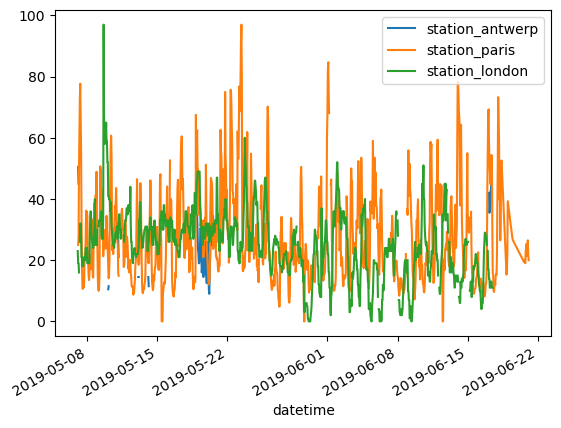

```python
air_quality.plot()
```

> pandas по умолчанию создает один линейный график для каждого из столбцов `DataFrame` с числовыми данными.

Отобразить только столбцы с данными из Парижа:

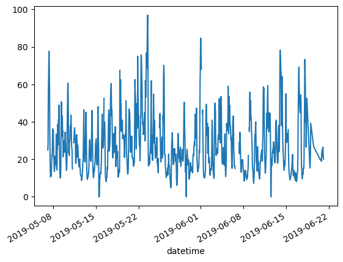

```python
air_quality["station_paris"].plot()
```

Визуально сравнить значения $NO_2$, измеренные в Лондоне и Париже:

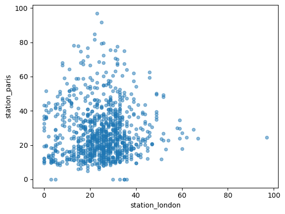

```python
air_quality.plot.scatter(x="station_london", y="station_paris", alpha=0.5)
```

Помимо линейного графика (`line`), предусмотренного по умолчанию при использовании функции `plot`, существует ряд альтернатив для построения данных. Давайте воспользуемся стандартным Python, чтобы получить обзор доступных методов построения графика:

```python
[
    method_name
    for method_name in dir(air_quality.plot)
    if not method_name.startswith("_")
]
```

```
['area',
 'bar',
 'barh',
 'box',
 'density',
 'hexbin',
 'hist',
 'kde',
 'line',
 'pie',
 'scatter']
```

Отдельные субдиаграммы для каждого из столбцов данных поддерживаются аргументом `subplots` функции `plot`.

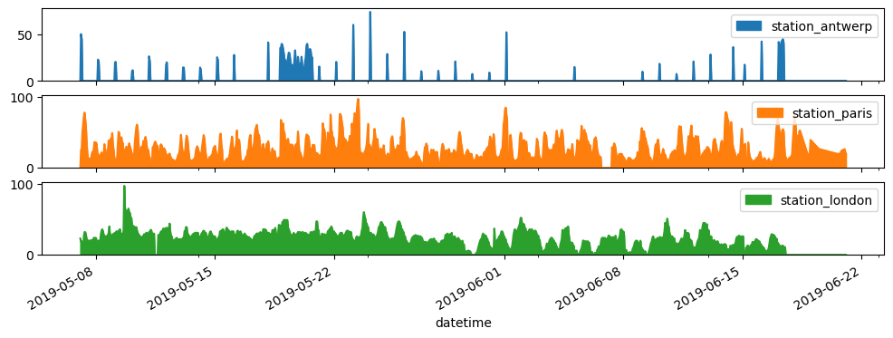

```python
axs = air_quality.plot.area(figsize=(12, 4), subplots=True)
```

Каждая диаграмма, созданная pandas, является объектом Matplotlib. Поскольку Matplotlib предоставляет множество опций для настройки диаграмм, явная связь между pandas и Matplotlib позволяет использовать всю мощь Matplotlib для диаграмм:

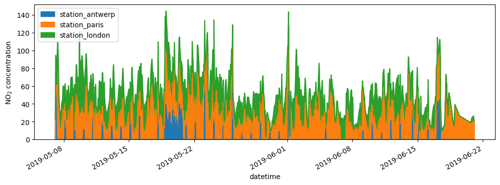

```python
fig, axs = plt.subplots(figsize=(12, 4))        # Create an empty matplotlib Figure and Axes
air_quality.plot.area(ax=axs)                   # Use pandas to put the area plot on the prepared Figure/Axes
axs.set_ylabel("NO$_2$ concentration")          # Do any matplotlib customization you like
fig.savefig("no2_concentrations.png")           # Save the Figure/Axes using the existing matplotlib method.
```

## 1.6 Как рассчитать сводную статистику?

```python
titanic
```

|  | PassengerId | Survived | Pclass | Name | Gender | Age | SibSp | Parch | Ticket | Fare | Cabin | Embarked |
| --- | --- | --- | --- | --- | --- | --- | --- | --- | --- | --- | --- | --- |
| 0 | 1 | 0 | 3 | anonymous | male | 22.0 | 1 | 0 | A/5 21171 | 7.2500 | NaN | S |
| 1 | 2 | 1 | 1 | anonymous | female | 38.0 | 1 | 0 | PC 17599 | 71.2833 | C85 | C |
| 2 | 3 | 1 | 3 | anonymous | female | 26.0 | 0 | 0 | STON/O2. 3101282 | 7.9250 | NaN | S |
| 3 | 4 | 1 | 1 | Futrelle, Mrs. Jacques Heath (Lily May Peel) | female | 35.0 | 1 | 0 | 113803 | 53.1000 | C123 | S |
| 4 | 5 | 0 | 3 | Allen, Mr. William Henry | male | 35.0 | 0 | 0 | 373450 | 8.0500 | NaN | S |
| ... | ... | ... | ... | ... | ... | ... | ... | ... | ... | ... | ... | ... |
| 886 | 887 | 0 | 2 | Montvila, Rev. Juozas | male | 27.0 | 0 | 0 | 211536 | 13.0000 | NaN | S |
| 887 | 888 | 1 | 1 | Graham, Miss. Margaret Edith | female | 19.0 | 0 | 0 | 112053 | 30.0000 | B42 | S |
| 888 | 889 | 0 | 3 | Johnston, Miss. Catherine Helen "Carrie" | female | NaN | 1 | 2 | W./C. 6607 | 23.4500 | NaN | S |
| 889 | 890 | 1 | 1 | Behr, Mr. Karl Howell | male | 26.0 | 0 | 0 | 111369 | 30.0000 | C148 | C |
| 890 | 891 | 0 | 3 | Dooley, Mr. Patrick | male | 32.0 | 0 | 0 | 370376 | 7.7500 | NaN | Q |

891 rows × 12 columns

### 1.6.1 Сводная статистика

[figure not shown]

К столбцам с числовыми данными можно применять различные статистические операции. По умолчанию исключаются отсутствующие данные и обрабатываются только строки.

Каков средний возраст пассажиров Титаника?

```python
titanic["Age"].mean()
```

```
29.69911764705882
```

[figure not shown]

```python
titanic[["Age", "Fare"]].median()
```

```
Age     28.0000
Fare    14.4542
dtype: float64
```

Статистические показатели, применяемые к нескольким столбцам `DataFrame` (выбор двух столбцов возвращает `DataFrame`), вычисляются для каждого столбца с числовыми значениями. Сводная статистика может быть рассчитана для нескольких столбцов одновременно.

```python
titanic[["Age", "Fare"]].describe()
```

|  | Age | Fare |
| --- | --- | --- |
| count | 714.000000 | 891.000000 |
| mean | 29.699118 | 32.204208 |
| std | 14.526497 | 49.693429 |
| min | 0.420000 | 0.000000 |
| 25% | 20.125000 | 7.910400 |
| 50% | 28.000000 | 14.454200 |
| 75% | 38.000000 | 31.000000 |
| max | 80.000000 | 512.329200 |

Вместо предопределенного набора статистических показателей можно задать собственную комбинацию для нескольких столбцов с помощью метода `DataFrame.agg()`:

```python
titanic.agg(
    {
        "Age": ["min", "max", "median", "skew"],
        "Fare": ["min", "max", "median", "mean"],
    }
)
```

|  | Age | Fare |
| --- | --- | --- |
| min | 0.420000 | 0.000000 |
| max | 80.000000 | 512.329200 |
| median | 28.000000 | 14.454200 |
| skew | 0.389108 | NaN |
| mean | NaN | 32.204208 |

Подробная информация об описательной статистике представлена в разделе руководства пользователя [об описательной статистике](https://pandas.pydata.org/pandas-docs/stable/user_guide/basics.html#basics-stats).

### 1.6.2 Подсчет количества записей по категориям

[figure not shown]

Метод `value_counts()` подсчитывает количество записей для каждой категории в столбце.

Каково количество пассажиров в каютах каждого класса?

```python
titanic["Pclass"].value_counts()
```

```
3    491
1    216
2    184
Name: Pclass, dtype: int64
```

Метод представляет собой сокращение, так как на самом деле это операция группировки в сочетании с подсчетом количества записей в каждой группе:

```python
titanic.groupby("Pclass")["Pclass"].count()
```

```
Pclass
1    216
2    184
3    491
Name: Pclass, dtype: int64
```

### 1.6.2 Описательная статистика

Объекты pandas оснащены набором общих математических и статистических методов. Большинство из них попадают в категорию сводной статистики. В отличие от соответствующих методов массивов NumPy методы объектов pandas имеют встроенную обработку пропущенных значений. Рассмотрим небольшой объект `DataFrame`:

```python
df = pd.DataFrame(
    [
        [1.4, np.nan],
        [7.1, -4.5],
        [np.nan, np.nan],
        [0.75, -1.3]
    ],
    index=['a', 'b', 'c', 'd'],
    columns=['one', 'two']
)
```

```python
df
```

|  | one | two |
| --- | --- | --- |
| a | 1.40 | NaN |
| b | 7.10 | -4.5 |
| c | NaN | NaN |
| d | 0.75 | -1.3 |

Вызов метода `sum` возвращает суммы значений по столбцам:

```python
df.sum()
```

```
one    9.25
two   -5.80
dtype: float64
```

Чтобы получить суммы значений по строкам нужно передать параметр `axis='columns'` или `axis=1`:

```python
df.sum(axis='columns')
```

```
a    1.40
b    2.60
c    0.00
d   -0.55
dtype: float64
```

```python
df.mean(axis='columns', skipna=False)
```

```
a      NaN
b    1.300
c      NaN
d   -0.275
dtype: float64
```

Некоторые методы, такие как `idxmin` и `idxmax`, возвращают косвенную статистику, такую как значение индекса, где достигаются минимальные или максимальные значения:

```python
df.idxmax()
```

```
one    b
two    d
dtype: object
```

Есть методы, являющиеся аккумулирующими:

```python
df.cumsum()
```

|  | one | two |
| --- | --- | --- |
| a | 1.40 | NaN |
| b | 8.50 | -4.5 |
| c | NaN | NaN |
| d | 9.25 | -5.8 |

Метод `describe` возвращает множественную суммарную статистику:

```python
df.describe()
```

|  | one | two |
| --- | --- | --- |
| count | 3.000000 | 2.000000 |
| mean | 3.083333 | -2.900000 |
| std | 3.493685 | 2.262742 |
| min | 0.750000 | -4.500000 |
| 25% | 1.075000 | -3.700000 |
| 50% | 1.400000 | -2.900000 |
| 75% | 4.250000 | -2.100000 |
| max | 7.100000 | -1.300000 |

Для нечисловых данных метод `describe` возвращает следующую информацию:

```python
obj = pd.Series(['a', 'a', 'b', 'c'] * 4)
```

```python
obj.describe()
```

```
count     16
unique     3
top        a
freq       8
dtype: object
```

**Методы описательной и сводной статистики**

[output not shown]